# Manual for Happinese (Friend edition)

Angel Wang

HappyDB is a corpus of 100,000 crowd-sourced happy moments via Amazon’s Mechanical Turk. You can read more about it on https://arxiv.org/abs/1801.07746.

Here, we explore this data set and try to answer the question, “What makes people happy?”

### Load all necessary packages

From the packages’ descriptions:

- `tidyverse` is an opinionated collection of R packages designed for data science. All packages share an underlying design philosophy, grammar, and data structures;
- `tidytext` allows text mining using ‘dplyr’, ‘ggplot2’, and other tidy tools;
- `DT` provides an R interface to the JavaScript library DataTables;
- `scales` map data to aesthetics, and provide methods for automatically determining breaks and labels for axes and legends;
- `wordcloud2` provides an HTML5 interface to wordcloud for data visualization;
- `gridExtra` contains miscellaneous functions for “grid” graphics;
- `ngram` is for constructing n-grams (“tokenizing”), as well as generating new text based on the n-gram structure of a given text input (“babbling”);

### Part 1 - Load the processed text data along with demographic information on contributors

First,I process the raw textual data ‘cleaned_hm.csv’ saved in $ data $ file by cleaning data, removing stopwords and creating a tidy version of texts which is saved in $ output $ file.

```r
hm_data <- read_csv("/Users/angelwang/Desktop/fall 2023/4243/ads-fall2023-project1-angelw29/output/processed_moments.csv")

urlfile<-'https://raw.githubusercontent.com/rit-public/HappyDB/master/happydb/data/demographic.csv'
demo_data <- read_csv(urlfile)
```

I choose a subset of the data out of the tidy version of texts and keep the required columns for analysis.

```r
hm_data <- hm_data %>%
  inner_join(demo_data, by = "wid") %>%
  select(wid,
         original_hm,
         gender,
         marital,
         parenthood,
         reflection_period,
         age,
         country,
         predicted_category,
         text) %>%
  mutate(count = sapply(hm_data$text, wordcount)) %>%
  filter(gender %in% c("m", "f")) %>%
  filter(marital %in% c("single", "married")) %>%
  filter(parenthood %in% c("n", "y")) %>%
  filter(reflection_period %in% c("24h", "3m")) %>%
  mutate(reflection_period = fct_recode(reflection_period,
                                        months_3 = "3m", hours_24 = "24h"))
```

### Part 2 - Explore the participants. Who’s and what kind happy moments are we looking at?

```
## [1] 94506
```

```
## [1] 38707
```

```
## [1] 55799
```

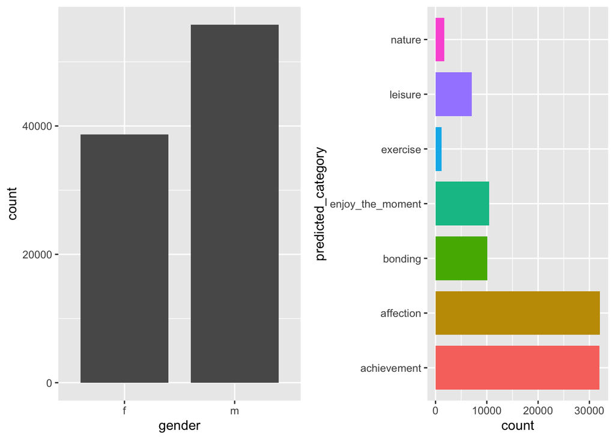

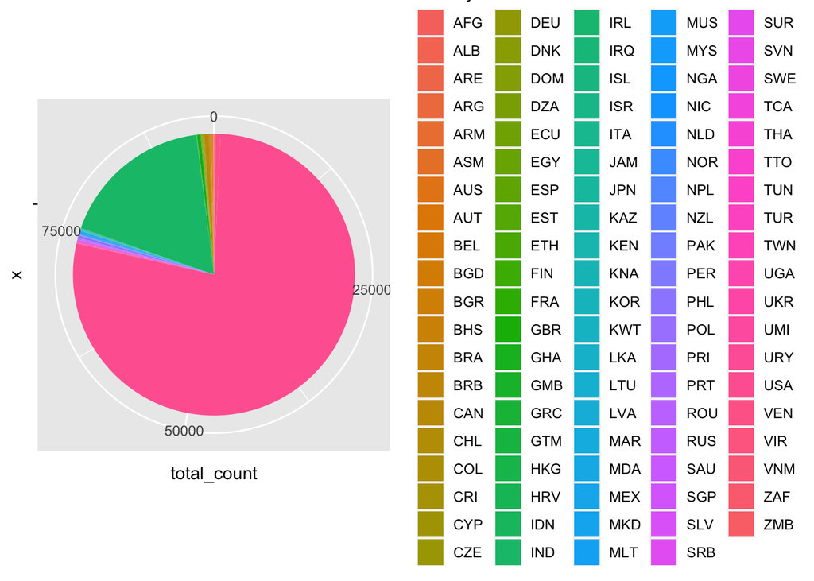

With in the 94506 cleaned-up happy moments, 38707 of those belongs to women and 55799 belongs to men. The pie chart shows that most happy moments are gathered from the United States, followed by India, the rest of the world only contributes few entries for this particular data set. From the category plot we can see that most happy moments are in either the category of affection or achievement. It is not surprising to me those these two categories make up the majority of the happy moments. For example, other categories like, nature and exercise, may not appear as a happy moment to someone (like me) that does not enjoy going out or think exercise is weary. How about taking a look at the words in each categories and see what excactly what brings them happiness?

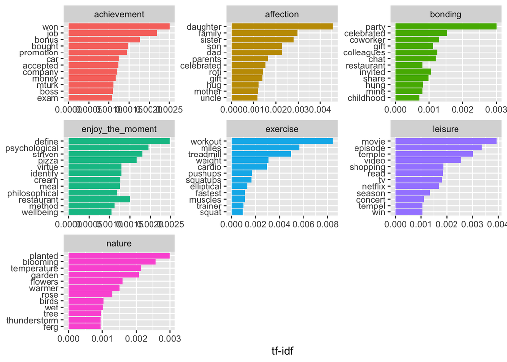

The tf-idf uses the frequency of words to determine how relevant those words are to a given document. I choose to look at the words that appears the most based on their categories. Since the majority of happy moments lays in affection and achievement category, I choose to look at them closely. The most word that occur the most for achievements are “won’,”job” and “bonus’. For affection, closely related people like”daughter”, “family” are the ones that got mentioned the most. I can totally related to the words and see how they got brought up the most.

Now, let’s take a look at the difference between men and women, since from personal experience what makes girls happy do not excites boys in the same way. Is there really a difference? if yes, how different?

### Part 3 - Subset the data. When do women feel happy? And when do men?

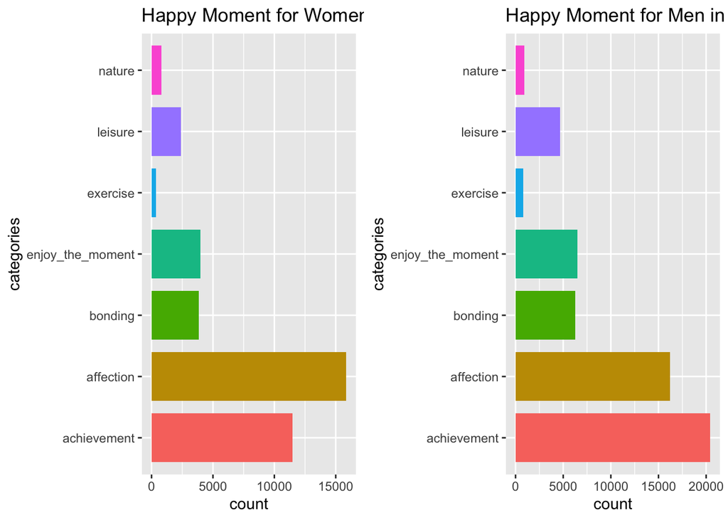

From the histogram we can see, for women most happy moments occur in affection and for men they occur in achievement. This makes more sense why boys are more competitive than girls, as winning something (won has highest TF-IDF within achievement category) can bring more them more happiness.

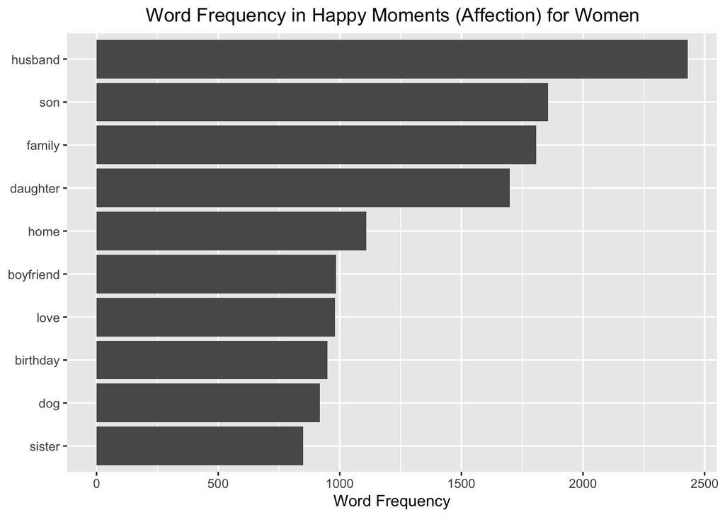

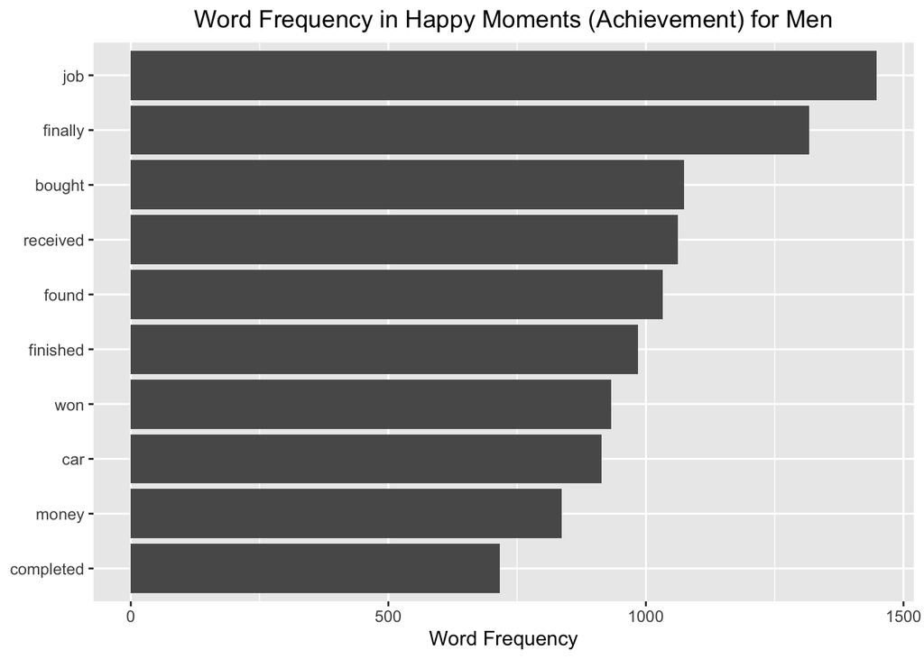

On the other hand, for men, I chose to look at the word frequency for achievement, since that is their top category for happy moments. We can see that, except for “car”, “job”, and “money”, most words are associated with an action (eg. “bought”, “received”, etc.) Getting something meaningful done allow men to feel more happiness, compared to women, we focus less on our achievement when thinking about happy moments.

Does that mean all men need is work? Probably not, since for them, the second most category is also affection. Therefore, maybe we should look at who are the people that can make men feel happy.

### Part 4 - Discover our similarity. Who is the ultimate one that can bring the happiness?

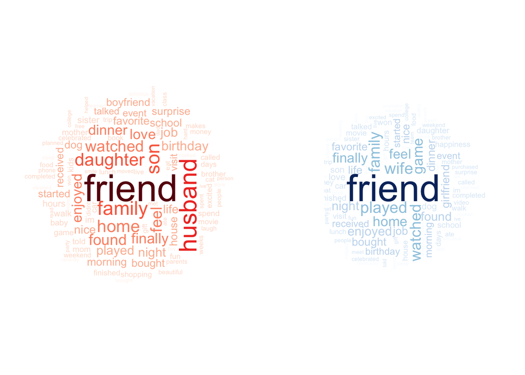

```
## $friend
##     term1         term2 similarity rank
## 1  friend         catch  0.9444382    1
## 2  friend         grand  0.9438220    2
## 3  friend     gathering  0.9373537    3
## 4  friend          chat  0.9349645    4
## 5  friend           fun  0.9345087    5
## 6  friend congratulated  0.9340953    6
## 7  friend    friendship  0.9330079    7
## 8  friend          hang  0.9278052    8
## 9  friend    girlfriend  0.9256599    9
## 10 friend    introduced  0.9236822   10
```

```
## $friend
##     term1   term2 similarity rank
## 1  friend     fun  0.9619870    1
## 2  friend   guest  0.9596086    2
## 3  friend     gap  0.9432051    3
## 4  friend  joyous  0.9429247    4
## 5  friend    fond  0.9256081    5
## 6  friend   guard  0.9250121    6
## 7  friend invited  0.9207969    7
## 8  friend closest  0.9196736    8
## 9  friend enjoyed  0.9195473    9
## 10 friend  family  0.9144704   10
```

Next, let’s take a look at the kind of activity different genders do with friend that brings the most fun.

### Part 5 - Take a closer look within the moments with friend

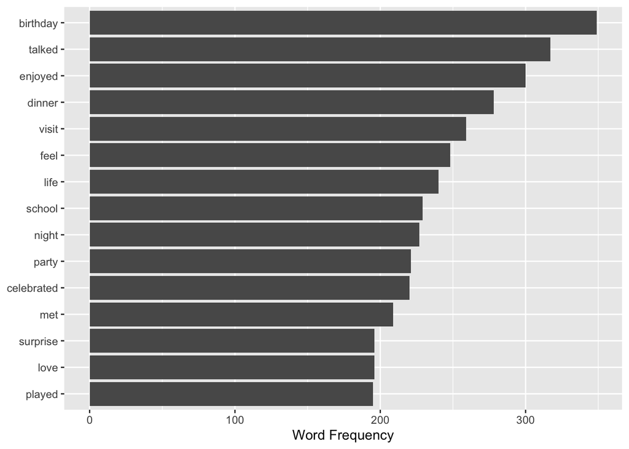

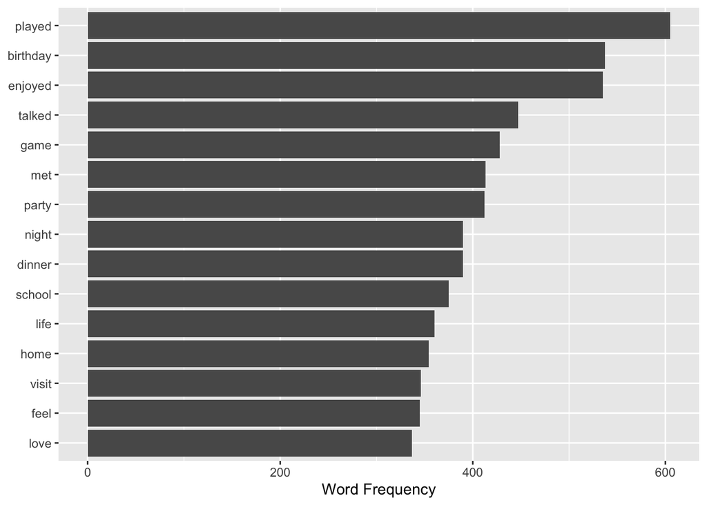

Except for special things like “birthday”, some activities that women enjoys with their friend are “surprise” and “celebrate”, and activities that men enjoys are “played” and “game”. There are also moments that both groups enjoy like “dinner” and “party”.

Using bigrams, the result also supports the same finding from above.

[figure not shown]

[figure not shown]

Below are some happy moments that related to dinner for women:

```
## # A tibble: 2 × 1
##   original_hm
##   <chr>
## 1 I made dinner for my boyfriend and he complimented me on it. I felt happy for…
## 2 I was happy because I went to dinner last night with friends I hadn't seen mo…
```

```
## # A tibble: 2 × 1
##   original_hm
##   <chr>
## 1 "we went for birthday party of my son's friend at  today 11.30 . I talked wit…
## 2 "I GOT GOVERNMENT JOB\r\nFRIENDS MEETING\r\nFRIENDS GET TO GATHER PARTY\r\nI'…
```

Below are some happy moments that related to dinner for men:

```
## # A tibble: 2 × 1
##   original_hm
##   <chr>
## 1 I took my girlfriend out for a nice Birthday dinner and got to watch her open…
## 2 I went out for dinner with my friends and enjoyed a lot.
```

```
## # A tibble: 2 × 1
##   original_hm
##   <chr>
## 1 My friends thrown a surprise party for my promotion yesterday, so happy.
## 2 partying all night with some old friends was one of the happy moments
```

### Part 6 - Difference based on region. Do we gain our happiness from same thing?

We know from the beginning that most entries are from USA, and since we are in the State, I’m also curious that whether the rest of the world and us share the source of happiness.

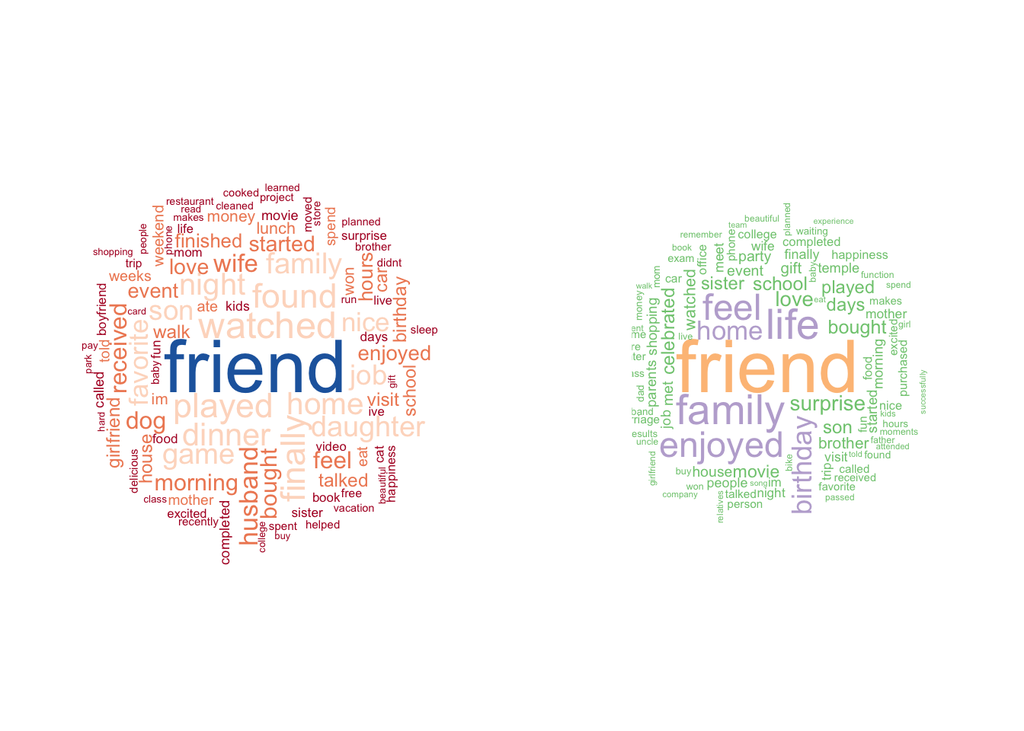

From the word clouds we can see that “friend” appears the most regard less of the region people are in. Those time spend with friend not only occur to us as happy moments, but also to the people in the other part of the world.

Below are some happy moments that associated with friend in US:

```r
hm_data_USA[grepl("friend",hm_data_USA$text),"original_hm"][1:5,]
```

```
## # A tibble: 5 × 1
##   original_hm
##   <chr>
## 1 "We were competing against another team in a online game, I was playing with …
## 2 "when i received flowers from my best friend"
## 3 "I saw two close friends that I haven't seen for a couple months."
## 4 "I cooked my girlfriend a wonderful breakfast."
## 5 "My girlfriend told me she loved me and that she hoped to marry me one day."
```

Below are some happy moments that associated with friend not in US:

```r
hm_data_notUSA[grepl("friend",hm_data_notUSA$text),"original_hm"][1:5,]
```

```
## # A tibble: 5 × 1
##   original_hm
##   <chr>
## 1 We had a serious talk with some friends of ours who have been flaky lately. T…
## 2 went to movies with my friends it was fun
## 3 A hot kiss with my girl friend last night made my day
## 4 We celebrated our anniversary with my boyfriend.
## 5 my son went to football match with his friends, he came home very happy that …
```